# Introduction to DS : Project

```python
import numpy as np
import pandas as pd
import matplotlib.pyplot as plt
from sklearn.preprocessing import StandardScaler
from sklearn.linear_model import LinearRegression
from sklearn.model_selection import train_test_split
from sklearn.metrics import r2_score, mean_squared_error
import seaborn as sns
%matplotlib inline

# Prepared scripts
import scripts as scr
```

## Data Prepatation

Data was inspected and we have the following observations based on that inspection

(1) We found that there are undesirable symbols, e.g '$' and '%', that make some varibles be of type 'object', rather than numerical variables.  
(2) In the treatment of numerical and categorical values within **script**, we allow for further treatment of some fields that are counted as exceptions  
(3) We clean the data in a way that variables with less than 80% of its values are dropped  
(4) We note that **calendar.listing_id** is to be joined with **listings.id**

```python
# Load data
calendar = pd.read_csv('00_Raw_Data/calendar.csv')
listings = pd.read_csv('00_Raw_Data/listings.csv')
reviews = pd.read_csv('00_Raw_Data/reviews.csv')
```

For the **calendar** data, the latter procedure is easy

```python
df_cal = scr.split_clean_data(calendar, subset= calendar.columns, cast_as_dt = ['date'])
df_cal
```

```
MSG: The column "price" was amended
```

|  | listing_id | date | price | available_t |
| --- | --- | --- | --- | --- |
| 0 | 241032 | 2016-01-04 | 85.000000 | True |
| 1 | 241032 | 2016-01-05 | 85.000000 | True |
| 2 | 241032 | 2016-01-06 | 137.944859 | False |
| 3 | 241032 | 2016-01-07 | 137.944859 | False |
| 4 | 241032 | 2016-01-08 | 137.944859 | False |
| ... | ... | ... | ... | ... |
| 1393565 | 10208623 | 2016-12-29 | 137.944859 | False |
| 1393566 | 10208623 | 2016-12-30 | 137.944859 | False |
| 1393567 | 10208623 | 2016-12-31 | 137.944859 | False |
| 1393568 | 10208623 | 2017-01-01 | 137.944859 | False |
| 1393569 | 10208623 | 2017-01-02 | 137.944859 | False |

1393570 rows × 4 columns

This is more difficult for the **listings**. We decided to take the following subset of variables

```python
listings.shape
```

```
(3818, 92)
```

```python
# Initial adhoc selection
listings_list =['id','experiences_offered', 'host_id', 'host_since',
                                         'host_response_time', 'host_response_rate','host_acceptance_rate',
                                         'host_is_superhost','host_listings_count','host_verifications', 'host_has_profile_pic',
                                         'property_type', 'accommodates', 'bathrooms', 'bedrooms','beds','square_feet',
                                         'guests_included', 'extra_people','price','weekly_price',
                                         'minimum_nights','maximum_nights','number_of_reviews','first_review','last_review','review_scores_rating',
                                         'review_scores_accuracy','review_scores_cleanliness','review_scores_checkin','review_scores_communication',
                                         'review_scores_location','review_scores_value','instant_bookable', 'cancellation_policy',
                                         'require_guest_profile_picture','require_guest_phone_verification','reviews_per_month']
len(listings_list)
```

```
38
```

```python
df_list = scr.split_clean_data(listings,
                               subset= listings_list,
                               cast_as_dt = ['host_since','first_review','last_review'])
df_list
```

```
MSG: The column "host_response_rate" was amended
MSG: The column "host_acceptance_rate" was amended
MSG: The column "extra_people" was amended
MSG: The column "price" was amended
MSG: The column "weekly_price" was amended
```

|  | id | host_id | host_since | host_response_time | host_response_rate | host_acceptance_rate | host_listings_count | host_verifications | property_type | accommodates | ... | review_scores_communication | review_scores_location | review_scores_value | cancellation_policy | reviews_per_month | host_is_superhost_t | host_has_profile_pic_t | instant_bookable_t | require_guest_profile_picture_t | require_guest_phone_verification_t |
| --- | --- | --- | --- | --- | --- | --- | --- | --- | --- | --- | --- | --- | --- | --- | --- | --- | --- | --- | --- | --- | --- |
| 0 | 241032 | 956883 | 2011-08-11 | within a few hours | 96.000000 | 100.000000 | 3.0 | ['email', 'phone', 'reviews', 'kba'] | Apartment | 4 | ... | 10.000000 | 9.000000 | 10.000000 | moderate | 4.070000 | False | True | False | False | False |
| 1 | 953595 | 5177328 | 2013-02-21 | within an hour | 98.000000 | 100.000000 | 6.0 | ['email', 'phone', 'facebook', 'linkedin', 're... | Apartment | 4 | ... | 10.000000 | 10.000000 | 10.000000 | strict | 1.480000 | True | True | False | True | True |
| 2 | 3308979 | 16708587 | 2014-06-12 | within a few hours | 67.000000 | 100.000000 | 2.0 | ['email', 'phone', 'google', 'reviews', 'jumio'] | House | 11 | ... | 10.000000 | 10.000000 | 10.000000 | strict | 1.150000 | False | True | False | False | False |
| 3 | 7421966 | 9851441 | 2013-11-06 | NaN | 94.886798 | 99.967159 | 1.0 | ['email', 'phone', 'facebook', 'reviews', 'jum... | Apartment | 3 | ... | 9.809599 | 9.608916 | 9.452245 | flexible | 2.078919 | False | True | False | False | False |
| 4 | 278830 | 1452570 | 2011-11-29 | within an hour | 100.000000 | 99.967159 | 2.0 | ['email', 'phone', 'facebook', 'reviews', 'kba'] | House | 6 | ... | 10.000000 | 9.000000 | 9.000000 | strict | 0.890000 | False | True | False | False | False |
| ... | ... | ... | ... | ... | ... | ... | ... | ... | ... | ... | ... | ... | ... | ... | ... | ... | ... | ... | ... | ... | ... |
| 3813 | 8101950 | 31148752 | 2015-04-13 | within a few hours | 99.000000 | 100.000000 | 354.0 | ['email', 'phone', 'linkedin', 'reviews', 'jum... | House | 6 | ... | 8.000000 | 10.000000 | 8.000000 | strict | 0.300000 | False | True | False | False | False |
| 3814 | 8902327 | 46566046 | 2015-10-14 | within an hour | 100.000000 | 100.000000 | 1.0 | ['email', 'phone', 'facebook', 'reviews', 'jum... | Apartment | 4 | ... | 10.000000 | 10.000000 | 10.000000 | moderate | 2.000000 | False | True | False | False | False |
| 3815 | 10267360 | 52791370 | 2015-12-30 | NaN | 94.886798 | 99.967159 | 1.0 | ['phone'] | House | 2 | ... | 9.809599 | 9.608916 | 9.452245 | moderate | 2.078919 | False | True | False | False | False |
| 3816 | 9604740 | 25522052 | 2015-01-03 | within an hour | 100.000000 | 99.967159 | 1.0 | ['email', 'phone', 'facebook', 'reviews', 'kba'] | Condominium | 2 | ... | 9.809599 | 9.608916 | 9.452245 | moderate | 2.078919 | False | True | False | False | False |
| 3817 | 10208623 | 14703116 | 2014-04-25 | within a day | 100.000000 | 99.967159 | 1.0 | ['email', 'phone', 'reviews', 'kba'] | Apartment | 3 | ... | 9.809599 | 9.608916 | 9.452245 | flexible | 2.078919 | False | True | False | False | False |

3818 rows × 36 columns

At last, we consider **reviews** data: to process review data and extract some utility from it, we will extract comments that reflect positive outlook. Such comments are the ones that contain the words 'cute', 'great', 'spa'

```python
list_rev = ['listing_id','id','date','reviewer_id','comments']
df_rev = scr.split_clean_data(reviews, subset= list_rev, cast_as_dt = ['date'], exc_list= ['comments'])
df_rev
```

|  | listing_id | id | date | reviewer_id | comments |
| --- | --- | --- | --- | --- | --- |
| 0 | 7202016 | 38917982 | 2015-07-19 | 28943674 | Cute and cozy place. Perfect location to every... |
| 1 | 7202016 | 39087409 | 2015-07-20 | 32440555 | Kelly has a great room in a very central locat... |
| 2 | 7202016 | 39820030 | 2015-07-26 | 37722850 | Very spacious apartment, and in a great neighb... |
| 3 | 7202016 | 40813543 | 2015-08-02 | 33671805 | Close to Seattle Center and all it has to offe... |
| 4 | 7202016 | 41986501 | 2015-08-10 | 34959538 | Kelly was a great host and very accommodating ... |
| ... | ... | ... | ... | ... | ... |
| 84844 | 3624990 | 50436321 | 2015-10-12 | 37419458 | The description and pictures of the apartment ... |
| 84845 | 3624990 | 51024875 | 2015-10-17 | 6933252 | We had an excellent stay. It was clean and com... |
| 84846 | 3624990 | 51511988 | 2015-10-20 | 19543701 | Gran ubicación, cerca de todo lo atractivo del... |
| 84847 | 3624990 | 52814482 | 2015-11-02 | 24445024 | Very good apartement, clean and well sized. Si... |
| 84848 | 9727246 | 56429621 | 2015-12-13 | 30860360 | Breanne was a great host. Check in was easy, s... |

84849 rows × 5 columns

# Question 1.

Do register reviewers feel overall content with the accomodation they found in Airbnb?

To answer this question we give a proxy for categorizing reviews as good: a review is considered to be good if it contains a particle in the list ['great','good','gran','cute', 'spacious','clean','comfortable']. Of course this proxy is not perfect: for example, one could attempt to use LLMs to score the sentiment on a review. Based on this clasification, we assign a 1 to positive reviews and a -1 for the rest, which is a proxy for a negative review. After this map, we construct a dataframe that contains a review 'score' at a given date for a givel listing simply by addign up all the assigned scores up to a given date.

```python
df = scr.query_positive(df_rev)
df[df.listing_id == 241032]
```

|  | listing_id | date | id | reviewer_id | sentiment_new |
| --- | --- | --- | --- | --- | --- |
| 9432 | 241032 | 2011-11-01 | 682061 | 479824 | -1.0 |
| 9433 | 241032 | 2011-11-04 | 1373773 | 837523 | 0.0 |
| 9434 | 241032 | 2011-11-08 | 2076772 | 2123090 | -1.0 |
| 9435 | 241032 | 2011-11-14 | 2794034 | 2770947 | -2.0 |
| 9436 | 241032 | 2011-11-19 | 3524260 | 4160768 | -3.0 |
| ... | ... | ... | ... | ... | ... |
| 9634 | 241032 | 2015-12-07 | 3544317364 | 1977510012 | 93.0 |
| 9635 | 241032 | 2015-12-17 | 3601082604 | 1980282031 | 94.0 |
| 9636 | 241032 | 2015-12-22 | 3658199335 | 2013672526 | 95.0 |
| 9637 | 241032 | 2015-12-24 | 3715556768 | 2023337390 | 96.0 |
| 9638 | 241032 | 2016-01-02 | 3773855445 | 2034443664 | 97.0 |

207 rows × 5 columns

To visualize this information, we now group by **date**

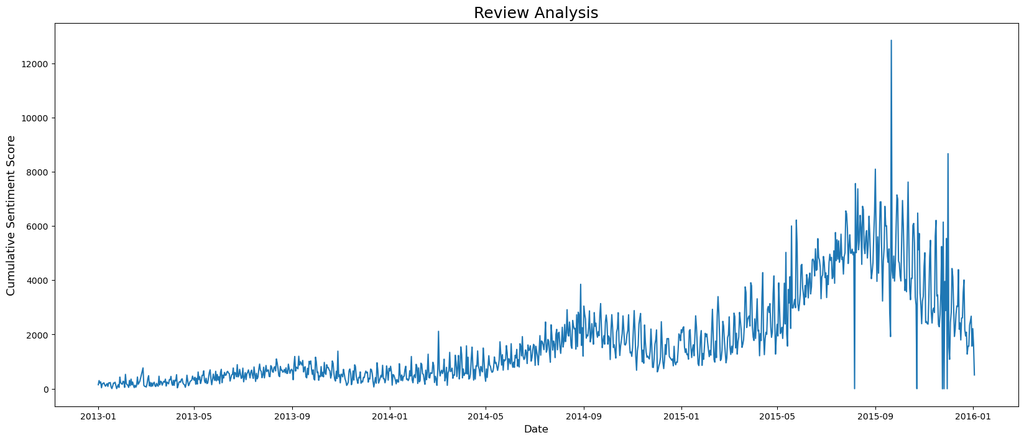

```python
dg = df.groupby(['date'], as_index= False).agg({'sentiment_new':'sum'})

# Visualizing
fig = plt.subplots(figsize=(20, 8))
sns.lineplot(x='date', y='sentiment_new', data=dg[(dg['date'].dt.year >= 2013)])
plt.title('Review Analysis', fontsize = 18)
plt.xlabel('Date', fontsize = 12)
plt.ylabel('Cumulative Sentiment Score', fontsize = 13)
plt.savefig('01_Visualization/Q1_1.png')
plt.show()
```

We notice that since 2013 the more and more users rated their Airbnb accomodation and the overall cumulative satisfaction and the overall satisfaction of such users is positive. Given the peak observed in 2015, one would be tempted to conclude that Airbnb had indeed became more popular by then. User's review are definitely a proxy from the demand side, but what about the offer's side? Are there simply more accomodations being listed in Airbnb during this period?

Sadly enough, we don't have data to answer this question during the time of interest, as the listing's data given is just for a given year, i.e. 2016. However, wo do notice that the number of listings in a given date is constant, which suggests that this data has been previously worked on.

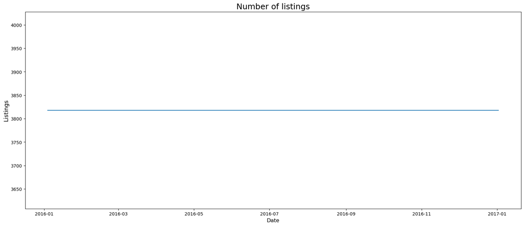

```python
dg = df_cal.groupby(['date'], as_index = False).agg({'listing_id':'nunique'})
dg= dg.rename(columns={'listing_id':'listing_number'})

# Visualizing
fig = plt.subplots(figsize=(20, 8))
sns.lineplot(x='date', y='listing_number', data=dg)
plt.title('Number of listings', fontsize = 18)
plt.xlabel('Date', fontsize = 12)
plt.ylabel('Listings', fontsize = 13)
plt.savefig('01_Visualization/Q1_2.png')
plt.show()
```

```python
# Sanity check
df_cal.loc[df_cal.date =='2016-01-04', 'listing_id'].unique().shape
```

```
(3818,)
```

# Question 2.

Airbnb has a genuine business interest in veryfing whether the price a host sets on a giving listing is in line with market expectations. In other words, is the price listed by the host reasonable enough for what he offers?

We analyze this question from two angles:  
(1) **Physical attributes.** Do the amenities offered in a listing has an influence in its listed price?  
(2) **Cancellation policy.** Does more flexibility impact price?

```python
# Little inspection
for col in df_list.columns:
    print(col, ':', df_list[col].iloc[0], df_list[col].shape)
```

```
id : 241032 (3818,)
host_id : 956883 (3818,)
host_since : 2011-08-11 00:00:00 (3818,)
host_response_time : within a few hours (3818,)
host_response_rate : 96.0 (3818,)
host_acceptance_rate : 100.0 (3818,)
host_listings_count : 3.0 (3818,)
host_verifications : ['email', 'phone', 'reviews', 'kba'] (3818,)
property_type : Apartment (3818,)
accommodates : 4 (3818,)
bathrooms : 1.0 (3818,)
bedrooms : 1.0 (3818,)
beds : 1.0 (3818,)
guests_included : 2 (3818,)
extra_people : 5.0 (3818,)
price : 85.0 (3818,)
weekly_price : 788.4818317570931 (3818,)
minimum_nights : 1 (3818,)
maximum_nights : 365 (3818,)
number_of_reviews : 207 (3818,)
first_review : 2011-11-01 00:00:00 (3818,)
last_review : 2016-01-02 00:00:00 (3818,)
review_scores_rating : 95.0 (3818,)
review_scores_accuracy : 10.0 (3818,)
review_scores_cleanliness : 10.0 (3818,)
review_scores_checkin : 10.0 (3818,)
review_scores_communication : 10.0 (3818,)
review_scores_location : 9.0 (3818,)
review_scores_value : 10.0 (3818,)
cancellation_policy : moderate (3818,)
reviews_per_month : 4.07 (3818,)
host_is_superhost_t : False (3818,)
host_has_profile_pic_t : True (3818,)
instant_bookable_t : False (3818,)
require_guest_profile_picture_t : False (3818,)
require_guest_phone_verification_t : False (3818,)
```

```python
subset = ['accommodates','bathrooms','bedrooms','beds',
          'guests_included','extra_people', 'maximum_nights', 'host_response_rate', 'host_acceptance_rate','price']

dg = df_list[subset].copy()
dg.head()
```

|  | accommodates | bathrooms | bedrooms | beds | guests_included | extra_people | maximum_nights | host_response_rate | host_acceptance_rate | price |
| --- | --- | --- | --- | --- | --- | --- | --- | --- | --- | --- |
| 0 | 4 | 1.0 | 1.0 | 1.0 | 2 | 5.0 | 365 | 96.000000 | 100.000000 | 85.0 |
| 1 | 4 | 1.0 | 1.0 | 1.0 | 1 | 0.0 | 90 | 98.000000 | 100.000000 | 150.0 |
| 2 | 11 | 4.5 | 5.0 | 7.0 | 10 | 25.0 | 30 | 67.000000 | 100.000000 | 975.0 |
| 3 | 3 | 1.0 | 0.0 | 2.0 | 1 | 0.0 | 1125 | 94.886798 | 99.967159 | 100.0 |
| 4 | 6 | 2.0 | 3.0 | 3.0 | 6 | 15.0 | 1125 | 100.000000 | 99.967159 | 450.0 |

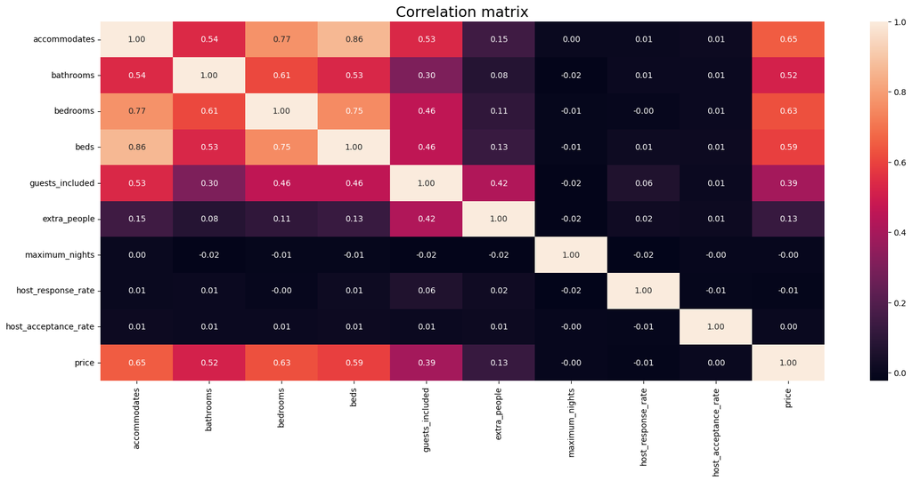

```python
# Correlation matrix
fig = plt.subplots(figsize=(20, 8))
sns.heatmap(dg.corr(), annot=True, fmt=".2f")
plt.title('Correlation matrix', fontsize = 18)
plt.savefig('01_Visualization/Q2_1.png')
plt.show()
```

The price of a listing is strongly correlated with the amenities it offers, as shown by the correlation between the price variable and the number of bedrooms, bathrooms, beds and the number of people that can be hosted in the property, respectively. Furthermore, some colinearity seems to be experienced between the latter 3 variables, just as expected.

This is useful to choose variables for a given model:

```python
# Selection variables
corr_pr = df_list.select_dtypes(include = ['int','float']).corr()['price']
corr_pr[abs(corr_pr)> 0.5]
```

```
accommodates    0.652218
bathrooms       0.516017
bedrooms        0.627596
beds            0.589306
price           1.000000
weekly_price    0.626361
Name: price, dtype: float64
```

At last let's see whether a cancelation policy makes the average price of an object higher or lower

```python
df_list.cancellation_policy.unique()
```

```
array(['moderate', 'strict', 'flexible'], dtype=object)
```

```python
dg = df_list.groupby(['cancellation_policy'], as_index = False).agg({'price':'mean','accommodates':'mean'}).round(0)
dg
```

|  | cancellation_policy | price | accommodates |
| --- | --- | --- | --- |
| 0 | flexible | 110.0 | 3.0 |
| 1 | moderate | 115.0 | 3.0 |
| 2 | strict | 155.0 | 4.0 |

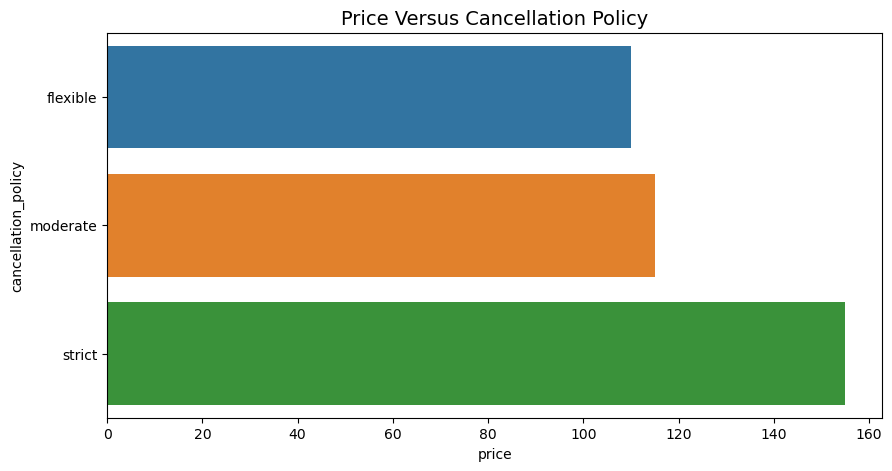

```python
# Visualization
fig = plt.subplots(figsize=(10, 5))
sns.barplot(data = dg, x="price", y="cancellation_policy")
plt.title('Price versus cancellation policy'.title(), fontsize = 14)
plt.savefig('01_Visualization/Q2_2.png')
plt.show();
```

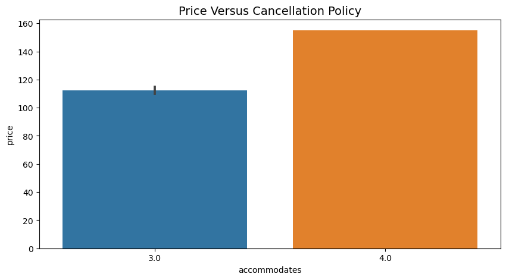

```python
# Visualization
fig = plt.subplots(figsize=(10, 5))
sns.barplot(data = dg, y="price", x="accommodates")
plt.title('Price versus cancellation policy'.title(), fontsize = 14)
plt.savefig('01_Visualization/Q2_2.png')
plt.show();
```

# Question 3.

From the perspective of Airbnb, one can put in place an alert for customers to tell them about unreasonable listing prices. An attempt to set a threshold can be done using a forecast model. But, how can we forecast listing price?

Now that we have analyzed relations of a listed price and the other variables, we recognized that price is mostly dependent on the number of people to be hosted. This is a simple enough model, but it should do the trick:

```python
# Response and explanatory variables
list_resp = ['price']
list_exp = ['accommodates']
```

```python
#Split into explanatory and response variables
X = df_list[list_exp]
y = df_list[list_resp]

#Split into train and test
X_train, X_test, y_train, y_test = train_test_split(X, y, test_size=0.3, random_state=123)

# Pre-process, instantiate and fit the model
scaler = StandardScaler()
X_train_scaled = scaler.fit_transform(X_train)
X_test_scaled = scaler.transform(X_test)
lm_model = LinearRegression()
lm_model.fit(X_train, y_train)

#Predict using your model
y_test_preds = lm_model.predict(X_test)
y_train_preds = lm_model.predict(X_train)

#Score using your model
test_score = r2_score(y_test, y_test_preds)*100
train_score = r2_score(y_train, y_train_preds)*100

print('The model has a training and test score of {:.2f}% and {:.2f}% resp. '.format(train_score, test_score))
```

```
The model has a training and test score of 40.48% and 46.30% resp.
```

The model is not perfect, but it does generalize well out-of sample

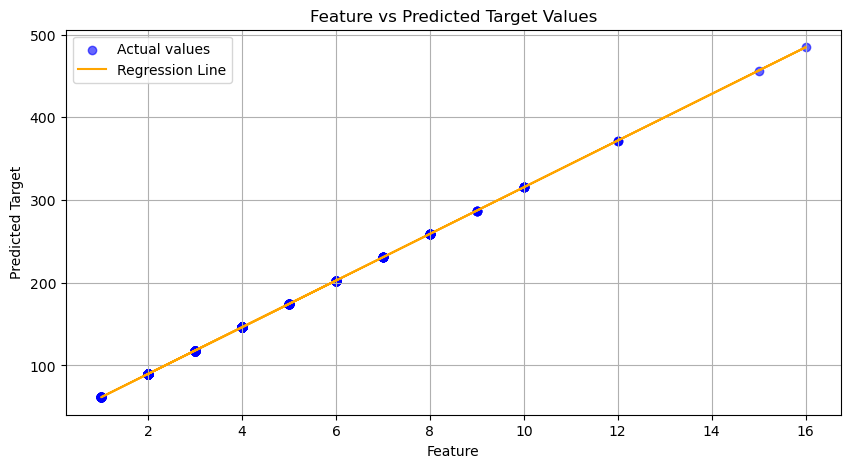

```python
# Visualizing
fig = plt.subplots(figsize=(10, 5))
plt.scatter(X_test, y_test_preds, color='blue', label='Actual values', alpha=0.6)  # Actual data points
plt.plot(X_test, y_test_preds, color='orange', label='Regression Line')  # Regression line
plt.xlabel('Feature')
plt.ylabel('Predicted Target')
plt.title('Feature vs Predicted Target Values')
plt.savefig('01_Visualization/Q3_1.png')
plt.legend()
plt.grid()
plt.show()
```